# CRWnotebook

## Background

[Chicago Restaurant Week](https://www.choosechicago.com/chicago-restaurant-week/) (hereafter, CRW) is an annual event during which diners explore prix-fixe menus at restaurants throughout Chicago. This year's CRW took place during Jan 24, 2020 – Feb 9, 2020.

Despite that information of all restaurants can be found on the official website, an in-depth data analysis of the restaurants that participated this event would be interesting in many ways. On a macro level, it helps understand Chicago's food culture, sheding light on restaurants' geographical distribution and its potential social implications. On a micro level, it enables customized recommendation for a specific user who wants to find a restaurant.

This project consists of 4 parts:

1. The data: Crawl restaurants' data from the official website
2. A bird's-eye view of the data: descriptive statistics and visualization
3. Aspect 1: What's new in the menu?: Analyzing menu texts (TODO)
4. Aspect 2: Which restaurant to go? Price, cuisine, and recommendation (TODO)

```python
# Load modules
import pandas as pd
import numpy as np
import re, os
import json
import matplotlib.pyplot as plt
import seaborn as sns
```

## 1. The data

The data was crawled from the website using Python ([code](https://github.com/yyd27/CRW2020)). Since the website was available only during CRW, the code does not work now (but maybe it will work again in 2021!)

The data come from three sources: 1) the index page of CRW ([code](https://github.com/yyd27/CRW2020/blob/master/src/step1_getData.py)), 2) the detail page of each restaurant ([code](https://github.com/yyd27/CRW2020/blob/master/src/step2_getDetails.py)), and 3) Yelp API ([code](https://github.com/yyd27/CRW2020/blob/master/src/step3_getYelp.py)). Below is detailed introduction of each data source and their roles.

1) The index of CRW. From the index page of the official website we can get basic information of restaurants, such as name, address, cuisine style, and url to detail page of each restaurant. There are 444 restaurants that participated CRW in total.

Below are some examples:

```python
df_Rindex = pd.read_csv("Rindex.txt", sep = "|")

print(df_Rindex.shape)
df_Rindex.head(n=5)
```

```
(444, 8)
```

|  | page | pg_id | name | cuisines | address | url | alt_option | meal_option |
| --- | --- | --- | --- | --- | --- | --- | --- | --- |
| 0 | 1 | 1 | 1776 Restaurant | ['American'] | 397 W Virginia Street | https://www.choosechicago.com/listing/1776-res... | ['Gluten-free'] | ['$36 Dinner'] |
| 1 | 1 | 2 | 20 East | ['American'] | 20 E. Delaware Pl. | https://www.choosechicago.com/listing/20-east/ | [] | ['$36 Dinner'] |
| 2 | 1 | 3 | 312 Chicago | ['Italian'] | 136 N. LaSalle St. | https://www.choosechicago.com/listing/312-chic... | [] | ['$36 Dinner'] |
| 3 | 1 | 4 | 676 Restaurant & Bar | ['American'] | 676 N. Michigan Ave. | https://www.choosechicago.com/listing/676-rest... | ['Vegetarian', 'Gluten-free'] | ['$24 Lunch', '$36 Dinner', '$48 Dinner'] |
| 4 | 1 | 5 | 90th Meridian | ['American Contemporary'] | 231 S. LaSalle St. Ste. 108 | https://www.choosechicago.com/listing/90th-mer... | [] | ['$24 Lunch'] |

2) The detail page of each restaurant. Each restaurant has a detailed page, which can be found on the index page, and it provides more detailed information. Two columns (neighborhood 'neighbor' and description 'des') are incorporated in the index data frame, and the rest are stored separately (under the "./Details/" directory) because of large variation among restaurants.

Below are some examples:

```python
df_Rdes = pd.read_csv("Rindex_w_des.txt", sep = "|")

print(df_Rdes.shape)
df_Rdes.head(n=5)
```

```
(444, 10)
```

|  | page | pg_id | name | cuisines | address | url | alt_option | meal_option | neighbor | des |
| --- | --- | --- | --- | --- | --- | --- | --- | --- | --- | --- |
| 0 | 1 | 1 | 1776 Restaurant | ['American'] | 397 W Virginia Street | https://www.choosechicago.com/listing/1776-res... | ['Gluten-free'] | ['$36 Dinner'] | Northwest Suburbs | We believe fine dining is more than the very b... |
| 1 | 1 | 2 | 20 East | ['American'] | 20 E. Delaware Pl. | https://www.choosechicago.com/listing/20-east/ | [] | ['$36 Dinner'] | River North | At 20 East, creative menus featuring quality-d... |
| 2 | 1 | 3 | 312 Chicago | ['Italian'] | 136 N. LaSalle St. | https://www.choosechicago.com/listing/312-chic... | [] | ['$36 Dinner'] | Loop | NaN |
| 3 | 1 | 4 | 676 Restaurant & Bar | ['American'] | 676 N. Michigan Ave. | https://www.choosechicago.com/listing/676-rest... | ['Vegetarian', 'Gluten-free'] | ['$24 Lunch', '$36 Dinner', '$48 Dinner'] | The Magnificent Mile | We are an American Contemporary restaurant wit... |
| 4 | 1 | 5 | 90th Meridian | ['American Contemporary'] | 231 S. LaSalle St. Ste. 108 | https://www.choosechicago.com/listing/90th-mer... | [] | ['$24 Lunch'] | Loop | Our menu has something for all diets and occas... |

All of these restaurants provided neighborhood information, while 16 (4%) of them did not provide a description:

```python
print(df_Rdes.loc[df_Rdes['neighbor'].isnull()].shape)
print(df_Rdes.loc[df_Rdes['des'].isnull()].shape)
```

```
(0, 10)
(16, 10)
```

As for detailed information, different restaurants provided very different information, ranging from 0 to 55 features. This piece of data is stored but not analyzed due to its complexity.

```python
ex1 = pd.read_csv("./Details/18.txt", sep = "|")
print(ex1.shape)
ex1.sample(n=5)
```

```
(49, 3)
```

|  | section | feature | value |
| --- | --- | --- | --- |
| 10 | Facility Meeting Space Details | Max Capacity, Classroom Style | 60.0 |
| 16 | Facility Meeting Space Details | On-Site Catering | NaN |
| 7 | Facility Meeting Space Details | Private Meeting Space Available | NaN |
| 11 | Facility Meeting Space Details | Max Capacity, Reception Style (Standing) | 100.0 |
| 23 | Facility Meeting Space Details | Number of Meeting Rooms | NaN |

```python
ex2 = pd.read_csv("./Details/307.txt", sep = "|")
print(ex2.shape)
ex2
```

```
(1, 3)
```

|  | section | feature | value |
| --- | --- | --- | --- |
| 0 | Certifications / Ratings | Zagat Rated | NaN |

3) Yelp API. The goal is to get more information of the restaurants and especially their non-CRW, daily-routine information. If a restaurant is not found in Yelp, then it's filled with a certain set of values.

```python
with open("yelp_best_match_json.txt") as rf1:
    dic = json.load(rf1)

df_yelp = pd.DataFrame.from_dict(dic, orient = 'index')
print(df_yelp.shape)
df_yelp.head(n=5)
```

```
(444, 6)
```

|  | Yname | Yaddress | price | rating | coordinates | review_count |
| --- | --- | --- | --- | --- | --- | --- |
| 0 | 1776 Restaurant | {'address1': '397 W Virginia St', 'address2': ... | $$$ | 4.0 | {'latitude': 42.233316, 'longitude': -88.335639} | 144 |
| 1 | 20 East | {'address1': '20 E Delaware Pl', 'address2': '... | $$ | 4.0 | {'latitude': 41.8994, 'longitude': -87.6275} | 63 |
| 10 | Ada Street | {'address1': '1664 N Ada St', 'address2': '', ... | $$$ | 4.0 | {'latitude': 41.9124416, 'longitude': -87.6620... | 515 |
| 100 | Coda Di Volpe | {'address1': '3335 N Southport Ave', 'address2... | $$ | 4.0 | {'latitude': 41.94265, 'longitude': -87.66354} | 276 |
| 101 | Cold Storage | {'address1': '1000 W Fulton Market', 'address2... | $$ | 4.0 | {'latitude': 41.88724, 'longitude': -87.65277} | 181 |

Combining these three sources of data, we get the final dataset.

```python
with open("final_data.txt") as rf1:
    dic = json.load(rf1)

df = pd.DataFrame.from_dict(dic, orient = 'index')
print(df.shape)
df.sample(n=5)
```

```
(444, 20)
```

|  | page | pg_id | name | cuisines | address | url | alt_option | meal_option | neighbor | des | ind | Yname | Yaddress | price | rating | coordinates | review_count | ratio_name | Yaddress1 | ratio_address |
| --- | --- | --- | --- | --- | --- | --- | --- | --- | --- | --- | --- | --- | --- | --- | --- | --- | --- | --- | --- | --- |
| 43 | 1 | 44 | Berghoff Restaurant | ['American', 'German'] | 17 W. Adams St. | https://www.choosechicago.com/listing/berghoff... | ['Gluten-free'] | ['$24 Lunch', '$36 Dinner'] | Loop | unknown | 43 | The Berghoff Restaurant | {'address1': '17 W Adams St', 'address2': '', ... | $$ | 3.5 | {'latitude': 41.8793326, 'longitude': -87.6286... | 1047.0 | 90 | 17 W Adams St | 93 |
| 428 | 9 | 29 | Vivere | ['Italian'] | 71 W. Monroe St. | https://www.choosechicago.com/listing/vivere/ | [] | ['$24 Lunch', '$48 Dinner'] | Loop | This is where we get very contemporary at the ... | 428 | Vivere | {'address1': '71 W Monroe St', 'address2': Non... | $$$ | 3.5 | {'latitude': 41.8803520202637, 'longitude': -8... | 142.0 | 100 | 71 W Monroe St | 93 |
| 425 | 9 | 26 | Victory Tap Chicago | ['Italian'] | 1416 S. Michigan Ave. | https://www.choosechicago.com/listing/victory-... | ['Vegetarian'] | ['$36 Dinner', '$48 Dinner'] | South Loop | A sophisticated sibling to the larger Armand’s... | 425 | Victory Tap Chicago | {'address1': '1416 S Michigan Ave', 'address2'... | $$ | 4.0 | {'latitude': 41.8635, 'longitude': -87.62454} | 270.0 | 100 | 1416 S Michigan Ave | 95 |
| 364 | 8 | 15 | Taste 222 | ['American'] | 222 N. Canal St. | https://www.choosechicago.com/listing/taste-222/ | ['Vegetarian', 'Gluten-free'] | ['$24 Lunch', '$48 Dinner'] | West Loop | Taste 222 is an intimate, upscale-chic restaur... | 364 | Taste 222 | {'address1': '222 N Canal St', 'address2': '',... | $$ | 4.0 | {'latitude': 41.886363, 'longitude': -87.64001} | 85.0 | 100 | 222 N Canal St | 93 |
| 218 | 5 | 19 | McCormick & Schmick’s Seafood & Steaks – Rosemont | ['Seafood'] | 5320 N. River Rd. | https://www.choosechicago.com/listing/mccormic... | [] | ['$24 Lunch', '$48 Dinner'] | Northwest Suburbs | McCormick and Schmicks is the Nation’s premier... | 218 | McCormick & Schmick's Seafood & Steaks | {'address1': '5320 N River Rd', 'address2': ''... | $$$ | 3.0 | {'latitude': 41.973998, 'longitude': -87.862742} | 296.0 | 85 | 5320 N River Rd | 94 |

A "ratio_name" value and a "ratio_address" value are calculated to show to what extent the restaurant's information from the official website matches that from Yelp. These values range from 0 to 100, and higher values indicate better match. We consider a match as failed only when both values are below 50.

There are two restaurants that failed to find a match in Yelp, and we exclude them from relevant analysis (e.g. those involving price and rating).

```python
df.loc[(df['ratio_address'] < 50) & (df['ratio_name'] < 50)]
```

|  | page | pg_id | name | cuisines | address | url | alt_option | meal_option | neighbor | des | ind | Yname | Yaddress | price | rating | coordinates | review_count | ratio_name | Yaddress1 | ratio_address |
| --- | --- | --- | --- | --- | --- | --- | --- | --- | --- | --- | --- | --- | --- | --- | --- | --- | --- | --- | --- | --- |
| 139 | 3 | 40 | Fogo de Chão | ['Brazilian'] | 1824 Abriter Ct. Ste. K200 | https://www.choosechicago.com/listing/fogo-de-... | [] | ['$48 Dinner'] | Southwest Suburbs | TBD | 139 | Fogo de Chao Brazilian Steakhouse | {'address1': '661 N Lasalle Blvd', 'address2':... | $$$ | 4.0 | {'latitude': 41.89418, 'longitude': -87.63251} | 1622.0 | 49 | 661 N Lasalle Blvd | 27 |
| 207 | 5 | 8 | Macello Cucina di Puglia | ['Italian'] | 1235 W. Lake St. | https://www.choosechicago.com/listing/macello-... | ['Vegetarian', 'Gluten-free'] | ['$24 Lunch', '$48 Dinner'] | West Loop | unknown | 207 | unknown | unknown | unknown | -1.0 | {'latitude': 0, 'longitude': 0} | -1.0 | 13 | unknown | 9 |

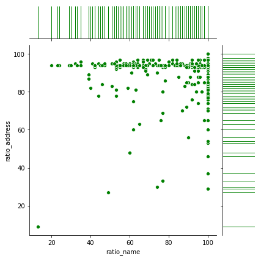

```python
# The distribution of ratio_name and ratio_address
grid = sns.JointGrid(df['ratio_name'], df['ratio_address'])
grid.plot_joint(sns.scatterplot, color="g")
grid.plot_marginals(sns.rugplot, height=1, color="g")
```

## 2. A bird's-eye view of the data: descriptive statistics and visualization

#### Where are the restaurants?: Geographic distribution

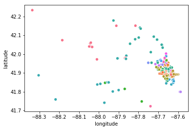

```python
df[["latitude","longitude"]] = df["coordinates"].apply(pd.Series)

df_in_Yelp = df.loc[(df['ratio_address'] >= 50) | (df['ratio_name'] >= 50)]

# Visualize
g = sns.scatterplot(x = "longitude",
                y = "latitude",
                hue = 'neighbor',
                marker = 'o',
                data = df_in_Yelp)
g.legend_.remove()
```

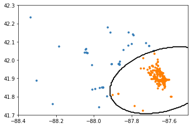

```python
from sklearn.covariance import EllipticEnvelope

X = df_in_Yelp[["longitude","latitude"]].values
clf = EllipticEnvelope(contamination = 0.1)
clf.fit(X)
y_pred = clf.predict(X)

# scatter
colors = np.array(['#377eb8', '#ff7f00'])
plt.scatter(X[:, 0], X[:, 1], s=10, color=colors[(y_pred + 1) // 2])

# contour
xx, yy = np.meshgrid(np.linspace(-88.4, -87.5, 150),
                     np.linspace(41.7, 42.3, 150))
Z = clf.predict(np.c_[xx.ravel(), yy.ravel()])
Z = Z.reshape(xx.shape)
plt.contour(xx, yy, Z, levels=[0], linewidths=2, colors='black')
```

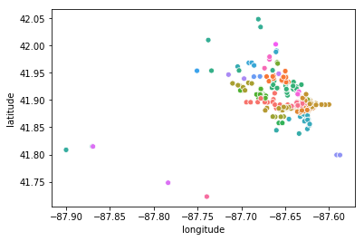

```python
# zoom in
df_downtown = df_in_Yelp.loc[y_pred == 1]
g = sns.scatterplot(x = "longitude",
                y = "latitude",
                hue = 'neighbor',
                marker = 'o',
                data = df_downtown)

g.legend_.remove()
```

```python
# What neighbors are excluded?
dfm1 = df_downtown.groupby(['neighbor'])['ind'].count().reset_index().sort_values(by='ind',ascending=False).rename(columns = {'ind':'count_dt'})
dfm2 = df_in_Yelp.groupby(['neighbor'])['ind'].count().reset_index().sort_values(by='ind',ascending=False).rename(columns = {'ind':'count_yelp'})
dfm_diff = pd.merge(dfm2, dfm1, how = 'left').fillna(0)
dfm_diff['diff'] = dfm_diff['count_yelp'] - dfm_diff['count_dt']
dfm_diff.loc[dfm_diff['diff'] > 0]
```

|  | neighbor | count_yelp | count_dt | diff |
| --- | --- | --- | --- | --- |
| 7 | Northwest Suburbs | 17 | 0.0 | 17.0 |
| 11 | West Suburbs | 15 | 2.0 | 13.0 |
| 13 | North Suburbs | 13 | 3.0 | 10.0 |
| 16 | O'Hare | 4 | 0.0 | 4.0 |
| 17 | Southwest Suburbs | 4 | 3.0 | 1.0 |

```python
dfm = df_downtown.groupby(['neighbor'])['ind'].count().reset_index().sort_values(by='ind',ascending=False).rename(columns = {'ind':'count'})
dfm
```

|  | neighbor | count |
| --- | --- | --- |
| 19 | River North | 93 |
| 28 | West Loop | 46 |
| 13 | Loop | 45 |
| 25 | Streeterville | 27 |
| 9 | Lincoln Park | 24 |
| 5 | Gold Coast | 22 |
| 8 | Lakeview | 20 |
| 31 | Wicker Park / Bucktown | 16 |
| 30 | West Town | 16 |
| 22 | South Loop | 16 |
| 26 | The Magnificent Mile | 14 |
| 12 | Logan Square | 12 |
| 11 | Little Italy / University Village | 4 |
| 15 | Old Town | 3 |
| 24 | Southwest Suburbs | 3 |
| 32 | Wrigleyville | 3 |
| 14 | North Suburbs | 3 |
| 10 | Lincoln Square | 3 |
| 7 | Irving Park | 3 |
| 21 | Roscoe Village | 3 |
| 27 | Uptown | 2 |
| 29 | West Suburbs | 2 |
| 16 | Pilsen | 2 |
| 1 | Andersonville | 2 |
| 6 | Hyde Park | 2 |
| 4 | Edgewater | 2 |
| 3 | Bridgeport | 2 |
| 2 | Avondale | 2 |
| 23 | South Suburbs | 1 |
| 20 | Rogers Park | 1 |
| 18 | Ravenswood | 1 |
| 17 | Portage Park | 1 |
| 0 | Albany Park | 1 |

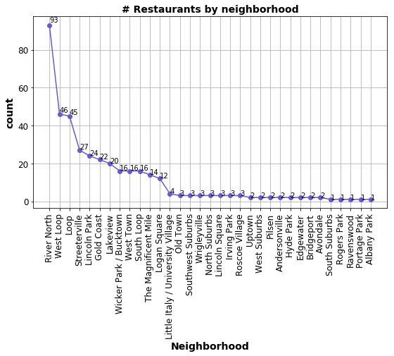

```python
fig, ax = plt.subplots(figsize=(9,5))
ax.plot(dfm['neighbor'], dfm['count'], 'o-', color = '#6A5ACD')
plt.xlabel("Neighborhood", fontsize = 14, fontweight="bold")
plt.ylabel("count", fontsize = 14, fontweight="bold")
plt.xticks(fontsize=12, rotation = 90)
plt.yticks(fontsize=12)
plt.title("# Restaurants by neighborhood", fontsize = 14, fontweight="bold")
plt.grid(True)

for i in range(dfm.shape[0]):
    plt.annotate(str(dfm.loc[i]['count']),
                 (dfm.loc[i]['neighbor'], dfm.loc[i]['count']*1.02),
                 fontsize = 10)
```

There are 3 neighborhoods with a lot of restaurants participating CRW: they are River North (93), West Loop (46), and Loop (45).

#### Price

```python
print(df_in_Yelp.groupby(['price'])['name'].count().reset_index().sort_values(by='name',ascending=False))
```

```
     price  name
0       $$   240
1      $$$   142
3  unknown    42
2     $$$$    18
```

I care about restaurants that are usually expensive. There (at least) 18 restaurants. I'll check and see what these restaurants are.

```python
df_in_Yelp.loc[df_in_Yelp['price'] == "$$$$", ['name', 'cuisines', 'neighbor', 'rating', 'review_count', 'meal_option']].sort_values(by = ['rating', 'review_count'], ascending=False)
```

|  | name | cuisines | neighbor | rating | review_count | meal_option |
| --- | --- | --- | --- | --- | --- | --- |
| 317 | RPM Steak | ['Steakhouse'] | River North | 4.5 | 1407.0 | ['$24 Lunch', '$48 Dinner'] |
| 288 | Prime & Provisions | ['Steakhouse'] | Loop | 4.5 | 1106.0 | ['$24 Brunch', '$24 Lunch', '$48 Dinner'] |
| 376 | The Capital Grille – Rosemont | ['American', 'Steakhouse'] | O'Hare | 4.5 | 452.0 | ['$24 Lunch', '$36 Dinner'] |
| 426 | Vie | ['American Contemporary'] | West Suburbs | 4.5 | 305.0 | ['$48 Dinner'] |
| 215 | Mastro’s Steakhouse | ['Steakhouse'] | River North | 4.0 | 1252.0 | ['$48 Dinner'] |
| 250 | NoMI Kitchen | ['French'] | The Magnificent Mile | 4.0 | 727.0 | ['$24 Lunch', '$36 Dinner', '$48 Dinner'] |
| 236 | Morton’s The Steakhouse – Chicago (The Original) | ['Steakhouse'] | Gold Coast | 4.0 | 300.0 | ['$48 Dinner'] |
| 179 | Katana | ['Asian Fusion'] | River North | 4.0 | 297.0 | ['$24 Lunch', '$48 Dinner'] |
| 158 | GT Prime | ['Steakhouse'] | River North | 4.0 | 273.0 | ['$48 Dinner'] |
| 255 | Odyssey Lake Michigan | ['American'] | Streeterville | 4.0 | 265.0 | ['$48 Dinner'] |
| 42 | Bellemore | ['American Contemporary'] | West Town | 4.0 | 227.0 | ['$24 Lunch', '$48 Dinner'] |
| 239 | Morton’s The Steakhouse – Rosemont | ['Steakhouse'] | Northwest Suburbs | 4.0 | 195.0 | ['$48 Dinner'] |
| 240 | Morton’s The Steakhouse – Schaumburg | ['Steakhouse'] | Northwest Suburbs | 4.0 | 164.0 | ['$48 Dinner'] |
| 61 | Brindille | ['French'] | River North | 4.0 | 156.0 | ['$48 Dinner'] |
| 412 | Topolobampo | ['Mexican'] | River North | 3.5 | 997.0 | ['$24 Lunch'] |
| 84 | Chicago Chop House | ['Steakhouse'] | River North | 3.5 | 745.0 | ['$48 Dinner'] |
| 253 | Oceanique Restaurant | ['Seafood'] | North Suburbs | 3.5 | 236.0 | ['$48 Dinner'] |
| 238 | Morton’s The Steakhouse – Northbrook | ['Steakhouse'] | North Suburbs | 3.5 | 132.0 | ['$48 Dinner'] |

We get a clear idea about which restaurants to go if we just care about the price.

#### Cuisines

Since a restaurant may have more than one cuisine style, we spread the cuisines column.

```python
df_cuisine = pd.concat([pd.Series(row['ind'], row['cuisines'].lstrip('[').rstrip("]").replace(" ","").split(","))
                    for _, row in df_in_Yelp.iterrows()]).reset_index()
df_cuisine.columns = ["cuisines","ind"]
df_cuisine = df_cuisine.drop_duplicates()
```

```python
print(df_cuisine.shape)
df_cuisine.groupby(['cuisines'])['ind'].count().reset_index().sort_values(by='ind',ascending=False)
```

```
(470, 2)
```

|  | cuisines | ind |
| --- | --- | --- |
| 1 | 'American' | 94 |
| 22 | 'Italian' | 64 |
| 2 | 'AmericanContemporary' | 61 |
| 36 | 'Steakhouse' | 47 |
| 32 | 'Seafood' | 28 |
| 27 | 'Mexican' | 24 |
| 15 | 'French' | 21 |
| 23 | 'Japanese/Sushi' | 16 |
| 16 | 'GastroTavern/Pub' | 13 |
| 26 | 'Mediterranean' | 9 |
| 25 | 'Latin' | 9 |
| 4 | 'BBQ/Ribs' | 8 |
| 31 | 'Pizza' | 8 |
| 35 | 'Spanish/Tapas' | 7 |
| 3 | 'AsianFusion' | 6 |
| 19 | 'Indian' | 4 |
| 39 | 'WineBar' | 4 |
| 9 | 'Chinese' | 4 |
| 17 | 'German' | 3 |
| 18 | 'Greek' | 3 |
| 34 | 'Southern' | 3 |
| 11 | 'Eclectic' | 3 |
| 7 | 'Brazilian' | 3 |
| 38 | 'Vietnamese' | 3 |
| 5 | 'Bakery/Café/Deli/Diner' | 3 |
| 29 | 'PanAsian' | 2 |
| 37 | 'Vegetarian/Vegan' | 2 |
| 33 | 'SoulFood' | 2 |
| 20 | 'InternationalFusion' | 2 |
| 21 | 'Irish' | 2 |
| 14 | 'FoodHall' | 2 |
| 12 | 'Filipino' | 2 |
| 28 | 'MiddleEastern' | 1 |
| 30 | 'Peruvian' | 1 |
| 24 | 'Korean' | 1 |
| 13 | 'Fondue' | 1 |
| 10 | 'DessertBar' | 1 |
| 8 | 'Cajun/Creole' | 1 |
| 6 | 'Bistro' | 1 |
| 0 | 'African' | 1 |

American cuisines dominate the restaurants!

#### Ratings

Most restaurants have a raing around 4, with few restaurants having ratings as low as 2.0.

```python
print(df_in_Yelp.groupby(['rating'])['ind'].count().reset_index().sort_values(by='rating',ascending=False))
```

```
   rating  ind
6     5.0    1
5     4.5   65
4     4.0  240
3     3.5  105
2     3.0   25
1     2.5    5
0     2.0    1
```

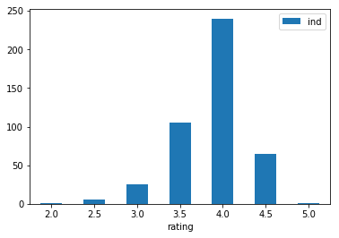

```python
df_in_Yelp.groupby(['rating'])['ind'].count().reset_index().plot.bar(x='rating', y='ind', rot=0)
```

```python
!jupyter nbconvert --execute --to html CRWnotebook.ipynb
```